# Kickstarter Logistic Regression

## Check Conditions for Logistic Regression

- Is `outcome` binary? Yes `outcome` is binary (success/fail)
- Linearity: Checked for quantitative predictors below, automatic for categorical predictors
- Independence of observations: It is reasonable to assume that Kickstarter campaigns independent.
- Randomness: We know that we didn’t capture all Kickstarter campaigns from 2009-2020, but the 170,000 scraped campaigns were selected randomly

### Check Linearity of Quantitative Predictors and log-odds

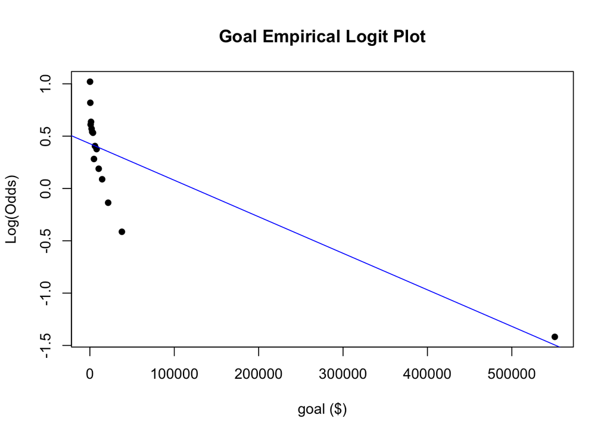

```r
# QUANT PREDICTOR 1 - GOAL
emplogitplot1(outcome ~ goal_usd, data = train, ngroups = 15, xlab = "goal ($)", main = "Goal Empirical Logit Plot")
```

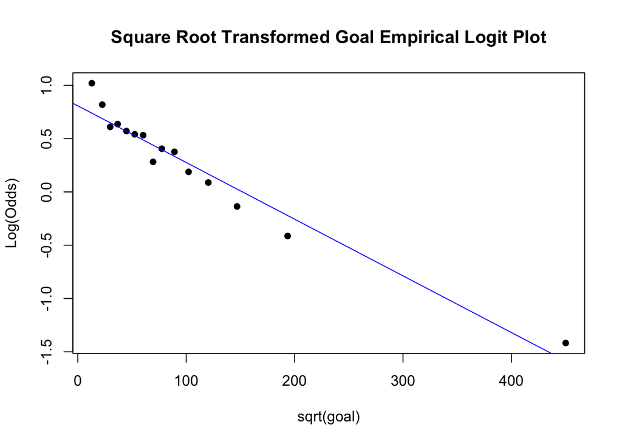

```r
# transform variable - for BOTH training and testing set
train <- train %>% mutate(sqrt_goal_usd = sqrt(goal_usd))
test <- test %>% mutate(sqrt_goal_usd = sqrt(goal_usd))

emplogitplot1(outcome ~ sqrt_goal_usd, data = train, ngroups = 15, xlab = "sqrt(goal)", main = "Square Root Transformed Goal Empirical Logit Plot")
```

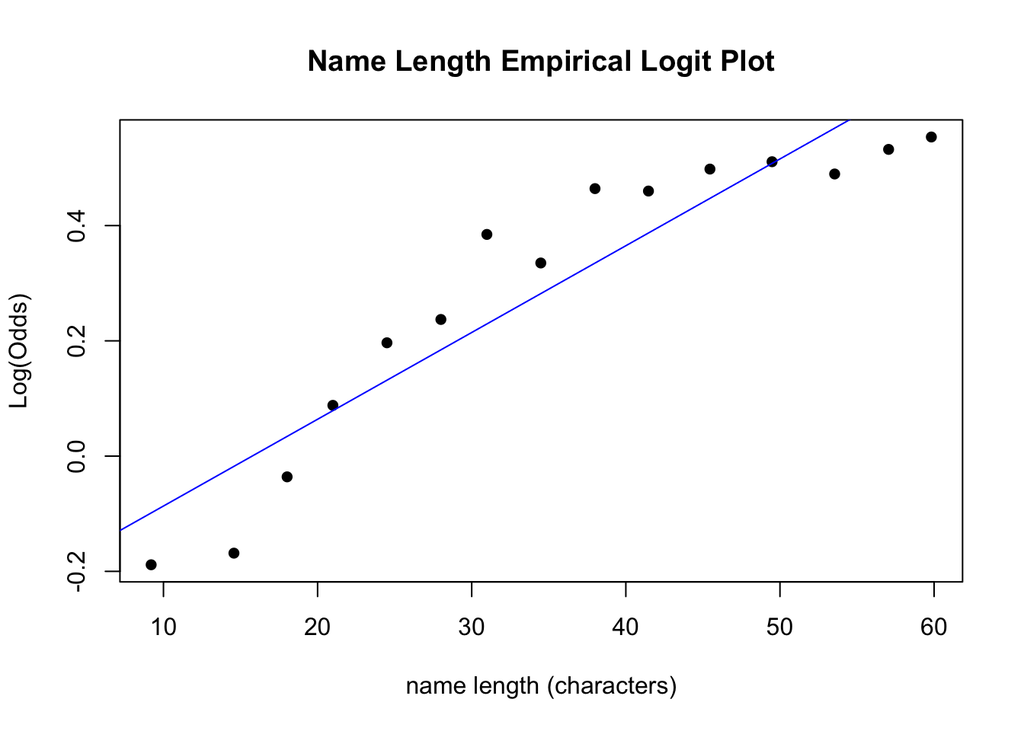

```r
# QUANT PREDICTOR 2 - NAME LENGTH
emplogitplot1(outcome ~ name_length, data = train, ngroups = 15, xlab = "name length (characters)", main = "Name Length Empirical Logit Plot")
```

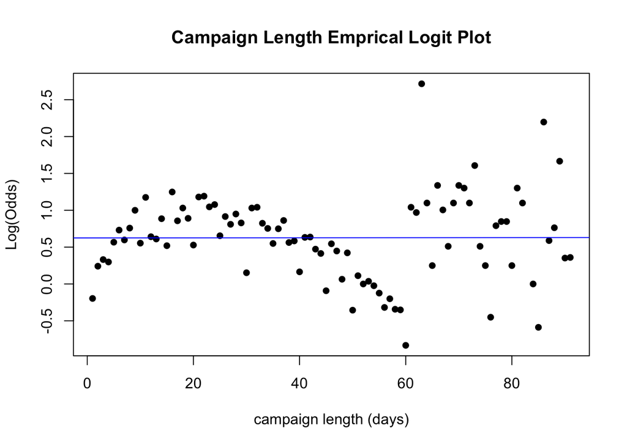

```r
# QUANT PREDICTOR 3 - CAMPAIGN LENGTH
emplogitplot1(outcome ~ campaign_length, data = train, xlab = "campaign length (days)", ngroups = "all", main = "Campaign Length Emprical Logit Plot")
```

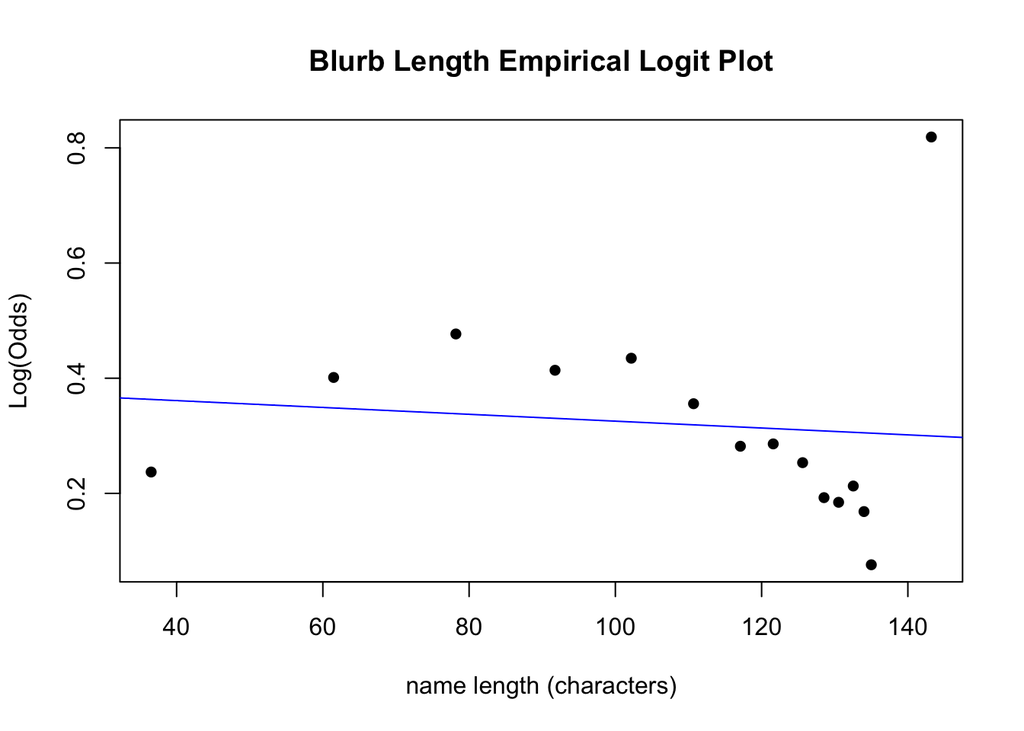

```r
# Blurb Length (no relationship)
emplogitplot1(outcome ~ blurb_length, data = train, ngroups = 15, xlab = "name length (characters)", main = "Blurb Length Empirical Logit Plot")
```

`goal_usd` does not initially have a linear relationship with the log odds of the outcome, so we applied a square root transformation. A square root transformation will inflate smaller goals and stabilize larger ones, which is helpful here because of the right skewed distribution of Kickstarter goals. The empirical logit plot for `campaign_length` looks concerning.

# EDA

## Response Variable - Kickstarter Campaign Outcome

```r
outcome_summary_tbl <- train %>% group_by(outcome) %>% summarise(n = n()) %>%
  mutate(freq = round(n/sum(n), 4),
         outcome = ifelse(outcome == 1, "Successful", "Failed")) %>%
  rename("Outcome" = outcome, "Number of Campaigns" = n, "Frequency of Campaigns" = freq)
outcome_summary_tbl
```

```
## # A tibble: 2 × 3
##   Outcome    `Number of Campaigns` `Frequency of Campaigns`
##   <chr>                      <int>                    <dbl>
## 1 Failed                     51354                    0.431
## 2 Successful                 67884                    0.569
```

56.9% of all Kickstarter campaigns in the training set were successful

## EDA for Categorical Variables

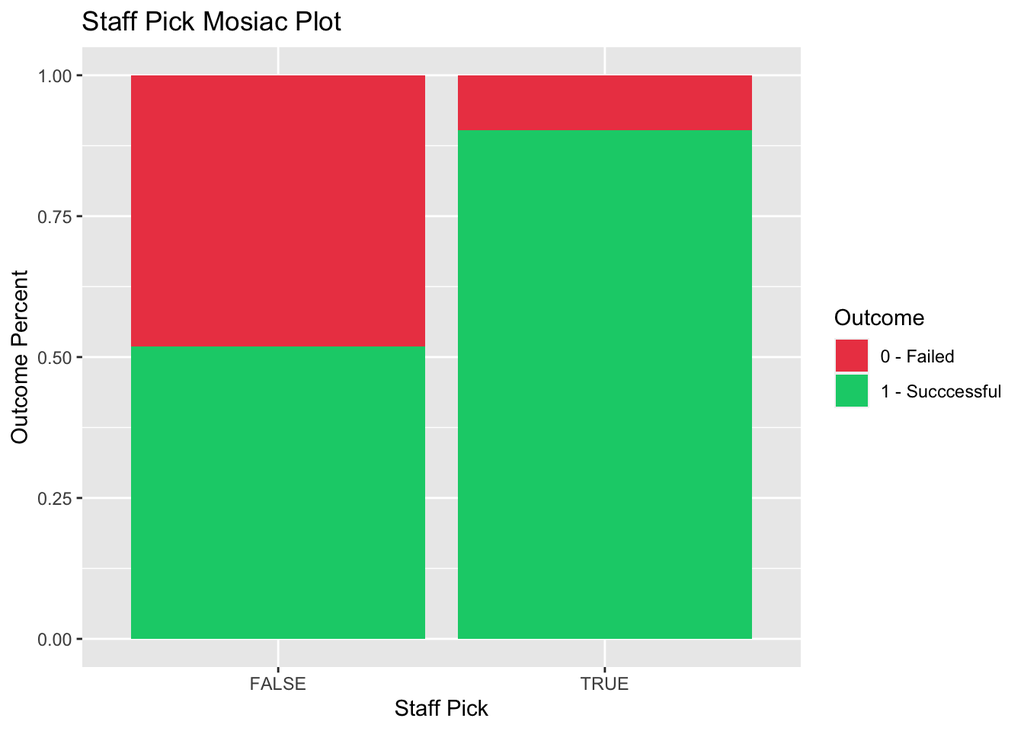

```r
# staff pick
gf_percents(~ staff_pick, fill = ~ as.factor(outcome), position = "fill", data = train, title = "Staff Pick Mosiac Plot", xlab = "Staff Pick", ylab = "Outcome Percent") +
  scale_fill_manual(name = "Outcome", labels = c("0 - Failed", "1 - Succcessful"), values = c("#ed4752", "#05ce78"))
```

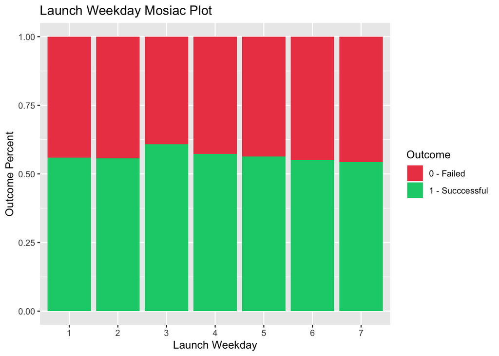

```r
# launch day of week
gf_percents(~ factor(launch_day), fill = ~ as.factor(outcome), position = "fill", data = train, title = "Launch Weekday Mosiac Plot", xlab = "Launch Weekday", ylab = "Outcome Percent") +
  scale_fill_manual(name = "Outcome", labels = c("0 - Failed", "1 - Succcessful"), values = c("#ed4752", "#05ce78"))
```

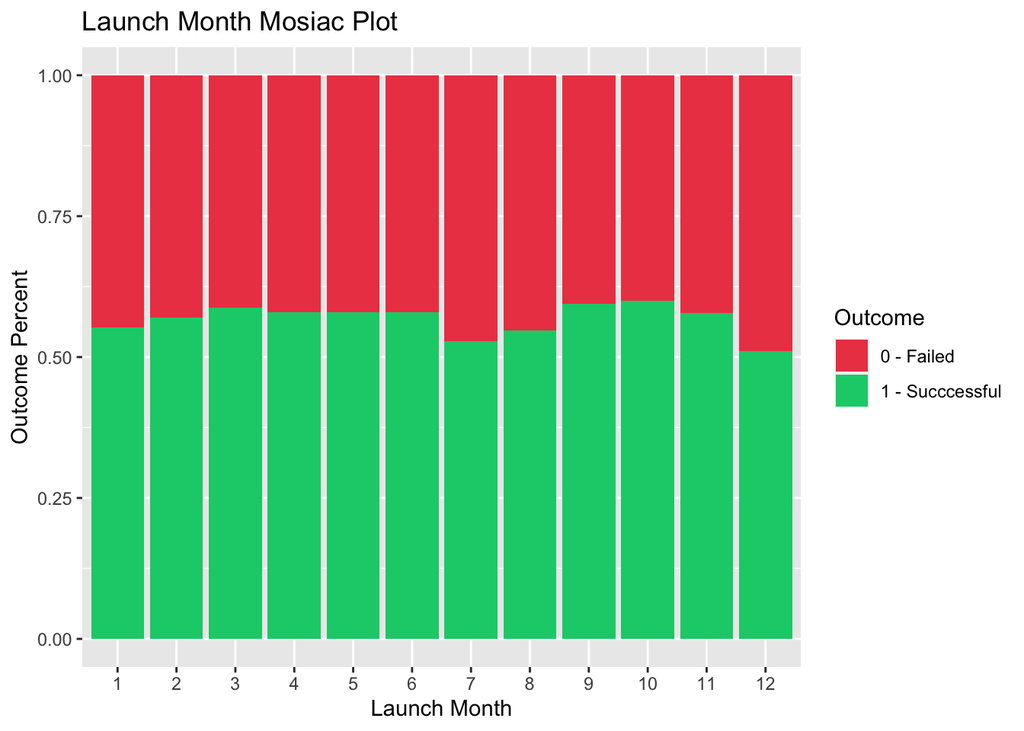

```r
# launch month
gf_percents(~ factor(launch_month), fill = ~ as.factor(outcome), position = "fill", data = train, title = "Launch Month Mosiac Plot", xlab = "Launch Month", ylab = "Outcome Percent") +
  scale_fill_manual(name = "Outcome", labels = c("0 - Failed", "1 - Succcessful"), values = c("#ed4752", "#05ce78"))
```

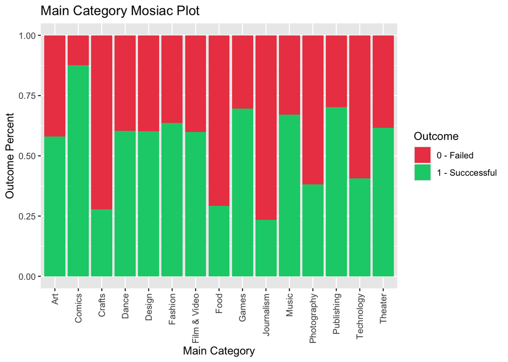

```r
# main category
gf_percents(~ main_category, fill = ~ as.factor(outcome), position = "fill", data = train, title = "Main Category Mosiac Plot", xlab = "Main Category", ylab = "Outcome Percent") +
  theme(axis.text.x = element_text(angle = 90, vjust = 0.5, hjust=1)) +
  scale_fill_manual(name = "Outcome", labels = c("0 - Failed", "1 - Succcessful"), values = c("#ed4752", "#05ce78"))
```

# Variable Selection

```r
# full model
mod.full <- glm(outcome ~ sqrt_goal_usd + name_length + campaign_length + staff_pick + launch_day + launch_month + main_category, data = train, family = "binomial")
summary(mod.full)
```

```
##
## Call:
## glm(formula = outcome ~ sqrt_goal_usd + name_length + campaign_length +
##     staff_pick + launch_day + launch_month + main_category, family = "binomial",
##     data = train)
##
## Deviance Residuals:
##     Min       1Q   Median       3Q      Max
## -3.1682  -0.9651   0.3670   0.9144   4.0118
##
## Coefficients:
##                             Estimate Std. Error z value             Pr(>|z|)
## (Intercept)                0.7978379  0.0365699  21.817 < 0.0000000000000002
## sqrt_goal_usd             -0.0083293  0.0001138 -73.189 < 0.0000000000000002
## name_length                0.0180041  0.0004465  40.319 < 0.0000000000000002
## campaign_length           -0.0214638  0.0005677 -37.811 < 0.0000000000000002
## staff_pickTRUE             2.6191984  0.0313335  83.591 < 0.0000000000000002
## launch_day                -0.0138895  0.0039125  -3.550             0.000385
## launch_month              -0.0020161  0.0020343  -0.991             0.321664
## main_categoryComics        1.4768945  0.0506136  29.180 < 0.0000000000000002
## main_categoryCrafts       -1.3404301  0.0455658 -29.417 < 0.0000000000000002
## main_categoryDance        -0.0819578  0.0697321  -1.175             0.239866
## main_categoryDesign        0.2369348  0.0396035   5.983      0.0000000021951
## main_categoryFashion       0.3828081  0.0332823  11.502 < 0.0000000000000002
## main_categoryFilm & Video  0.4844212  0.0263378  18.393 < 0.0000000000000002
## main_categoryFood         -0.9029652  0.0321015 -28.128 < 0.0000000000000002
## main_categoryGames         0.7975159  0.0335404  23.778 < 0.0000000000000002
## main_categoryJournalism   -1.5174816  0.0583814 -25.993 < 0.0000000000000002
## main_categoryMusic         0.5555906  0.0259327  21.424 < 0.0000000000000002
## main_categoryPhotography  -0.8687882  0.0409098 -21.237 < 0.0000000000000002
## main_categoryPublishing    0.4651469  0.0287300  16.190 < 0.0000000000000002
## main_categoryTechnology   -0.2035645  0.0290679  -7.003      0.0000000000025
## main_categoryTheater       0.2652561  0.0442557   5.994      0.0000000020510
##
## (Intercept)               ***
## sqrt_goal_usd             ***
## name_length               ***
## campaign_length           ***
## staff_pickTRUE            ***
## launch_day                ***
```

[output cut: 10 more lines]

```
## main_categoryMusic        ***
## main_categoryPhotography  ***
## main_categoryPublishing   ***
## main_categoryTechnology   ***
## main_categoryTheater      ***
## ---
## Signif. codes:  0 '***' 0.001 '**' 0.01 '*' 0.05 '.' 0.1 ' ' 1
##
## (Dispersion parameter for binomial family taken to be 1)
##
##     Null deviance: 163000  on 119237  degrees of freedom
## Residual deviance: 130282  on 119217  degrees of freedom
## AIC: 130324
##
## Number of Fisher Scoring iterations: 6
```

```r
mod.small <- glm(outcome ~ sqrt_goal_usd + name_length + campaign_length + staff_pick + launch_day + launch_month, data = train, family = "binomial")
summary(mod.small)
```

```
##
## Call:
## glm(formula = outcome ~ sqrt_goal_usd + name_length + campaign_length +
##     staff_pick + launch_day + launch_month, family = "binomial",
##     data = train)
##
## Deviance Residuals:
##     Min       1Q   Median       3Q      Max
## -2.9187  -1.0990   0.3969   0.9943   4.2707
##
## Coefficients:
##                   Estimate Std. Error z value             Pr(>|z|)
## (Intercept)      1.0217568  0.0309377  33.026 < 0.0000000000000002 ***
## sqrt_goal_usd   -0.0088612  0.0001069 -82.868 < 0.0000000000000002 ***
## name_length      0.0163751  0.0004196  39.029 < 0.0000000000000002 ***
## campaign_length -0.0211744  0.0005445 -38.888 < 0.0000000000000002 ***
## staff_pickTRUE   2.5921712  0.0305983  84.716 < 0.0000000000000002 ***
## launch_day      -0.0120043  0.0037526  -3.199              0.00138 **
## launch_month    -0.0015807  0.0019525  -0.810              0.41819
## ---
## Signif. codes:  0 '***' 0.001 '**' 0.01 '*' 0.05 '.' 0.1 ' ' 1
##
## (Dispersion parameter for binomial family taken to be 1)
##
##     Null deviance: 163000  on 119237  degrees of freedom
## Residual deviance: 138888  on 119231  degrees of freedom
## AIC: 138902
##
## Number of Fisher Scoring iterations: 6
```

```r
mod.final <- glm(outcome ~ sqrt_goal_usd + name_length + campaign_length + staff_pick + launch_day + main_category, data = train, family = "binomial")
summary(mod.final)
```

```
##
## Call:
## glm(formula = outcome ~ sqrt_goal_usd + name_length + campaign_length +
##     staff_pick + launch_day + main_category, family = "binomial",
##     data = train)
##
## Deviance Residuals:
##     Min       1Q   Median       3Q      Max
## -3.1704  -0.9652   0.3670   0.9142   4.0142
##
## Coefficients:
##                             Estimate Std. Error z value             Pr(>|z|)
## (Intercept)                0.7849874  0.0341910  22.959 < 0.0000000000000002
## sqrt_goal_usd             -0.0083314  0.0001138 -73.216 < 0.0000000000000002
## name_length                0.0180016  0.0004465  40.315 < 0.0000000000000002
## campaign_length           -0.0214565  0.0005676 -37.802 < 0.0000000000000002
## staff_pickTRUE             2.6190649  0.0313339  83.586 < 0.0000000000000002
## launch_day                -0.0138584  0.0039123  -3.542             0.000397
## main_categoryComics        1.4764930  0.0506116  29.173 < 0.0000000000000002
## main_categoryCrafts       -1.3406694  0.0455659 -29.423 < 0.0000000000000002
## main_categoryDance        -0.0815543  0.0697329  -1.170             0.242192
## main_categoryDesign        0.2360594  0.0395931   5.962     0.00000000248960
## main_categoryFashion       0.3823124  0.0332778  11.489 < 0.0000000000000002
## main_categoryFilm & Video  0.4843428  0.0263371  18.390 < 0.0000000000000002
## main_categoryFood         -0.9032079  0.0321009 -28.137 < 0.0000000000000002
## main_categoryGames         0.7968217  0.0335332  23.762 < 0.0000000000000002
## main_categoryJournalism   -1.5176966  0.0583816 -25.996 < 0.0000000000000002
## main_categoryMusic         0.5555697  0.0259324  21.424 < 0.0000000000000002
## main_categoryPhotography  -0.8690283  0.0409098 -21.243 < 0.0000000000000002
## main_categoryPublishing    0.4648355  0.0287280  16.181 < 0.0000000000000002
## main_categoryTechnology   -0.2041175  0.0290623  -7.023     0.00000000000216
## main_categoryTheater       0.2656294  0.0442534   6.002     0.00000000194354
##
## (Intercept)               ***
## sqrt_goal_usd             ***
## name_length               ***
## campaign_length           ***
## staff_pickTRUE            ***
## launch_day                ***
## main_categoryComics       ***
```

[output cut: 8 more lines]

```
## main_categoryMusic        ***
## main_categoryPhotography  ***
## main_categoryPublishing   ***
## main_categoryTechnology   ***
## main_categoryTheater      ***
## ---
## Signif. codes:  0 '***' 0.001 '**' 0.01 '*' 0.05 '.' 0.1 ' ' 1
##
## (Dispersion parameter for binomial family taken to be 1)
##
##     Null deviance: 163000  on 119237  degrees of freedom
## Residual deviance: 130283  on 119218  degrees of freedom
## AIC: 130323
##
## Number of Fisher Scoring iterations: 6
```

Using a Wald test for each predictor, all predictors are significant at an alpha level of 0.05, with the exception of launch_month and a single level of the `main_category` predictor. We will remove launch_month since it is not significant. There does not appear to be a significant difference between the dance category and our baseline category, art. In order to see if we should keep the predictor `main_category` in our model, we will perform a nested likelihood ratio test (LRT).

```r
# nested LRT
lrtest(mod.full, mod.small)
```

```
## Likelihood ratio test
##
## Model 1: outcome ~ sqrt_goal_usd + name_length + campaign_length + staff_pick +
##     launch_day + launch_month + main_category
## Model 2: outcome ~ sqrt_goal_usd + name_length + campaign_length + staff_pick +
##     launch_day + launch_month
##   #Df LogLik  Df  Chisq            Pr(>Chisq)
## 1  21 -65141
## 2   7 -69444 -14 8605.9 < 0.00000000000000022 ***
## ---
## Signif. codes:  0 '***' 0.001 '**' 0.01 '*' 0.05 '.' 0.1 ' ' 1
```

The nested LRT returns a significant p-value, meaning that the additional predictor, `main_cateogry`, significantly helps in the prediction of the log(odds) of the outcome. Therefore, we will keep `main_category` in our model and remove `launch_month` in the final model. The final model has the lowest AIC, so we will proceed with that model.